# Gene prediction and functionnal annotation workflow

The variables necessary are :

- the sample names
- the types of predictions

The script also needs to know where to find the prediction tables.

```r
library(readr)
library(dplyr)
library(tidyr)
library(stringr)
library(colorspace)
library(ggplot2)
library(reticulate)
library(UpSetR)
library(reshape)
library(knitr)
library(pheatmap)
library(gridExtra)
library(VennDiagram)

#Different list of sample names
reference_sample = "Zt09"
our_samples = c("Zt10", "Zt05", "Zp13", "Zb87", "Za17", "Zpa63")
samples = c("Zt09", "Zt05", "Zt10", "Zp13", "Zb87", "Za17", "Zpa63")
samples_out = c("Zt09", "Zt05", "Zt10",
                "Zp13", "Zb87", "Za17",
                "Zpa63", "CB0940") # All samples with the outgroup

#Colors
my_colors = c("#8AB661", "#FABE0E", "#FD8664", "#19535F", "#17A398")
my_dark_colors = darken(my_colors)
q4 <- sequential_hcl(5, "SunsetDark")
```

## Assembly statistics

### Filtering

First, let’s start by some statistics about assemblies and assembly filtering. The raw assemblies are polished through either arrow or quiver. We have then filtered our polished assemblies based on the coverage: contigs with too high coverage (possibly artifacts due to spurious assemblies of repeats) and too low coverage (in which the quality might be too low) have been removed.

```r
#Gathering raw polished assembly statistics
for (sample in our_samples) {
  file_name = list.files(ASpolished_dir,
             pattern = paste0(AS_stat_file_prefix,
                               sample, "*"))[1]

  predictions = read_delim(paste0(ASpolished_dir, file_name), ":",
                         skip = 1,
                         col_names = FALSE)
  predictions$X2 = trimws(predictions$X2, which = "both")
  colnames(predictions) = c("Statistic", sample)

  if (sample == our_samples[[1]]) {
    results = predictions
  }
  else {
    results = full_join(results, predictions)}
}
results$Assembly_type = "Polished"


#Gathering post-filtering assembly statistics
for (sample in our_samples) {
file_name = list.files(ASfiltered_dir,
           pattern = paste0(AS_stat_file_prefix,
                             sample, "*"))[1]
predictions = read_delim(paste0(ASfiltered_dir, file_name), ":",
                       skip = 1,
                       col_names = FALSE)
predictions$X2 = trimws(predictions$X2, which = "both")
colnames(predictions) = c("Statistic", sample)

if (sample == our_samples[[1]]) {
  results2 = predictions
}
else { results2 = full_join(results2, predictions)}
}
results2$Assembly_type = "Filtered"

#Putting everything together!
results = rbind(results, results2)
results = results[, c(1, ncol(results), 2:(ncol(results)-1) )]
write.table(results,
            file = paste0(assemblies_dir, "Assemblies_sum_table.txt"),
            sep = "\t",
            quote = FALSE,
            row.names = FALSE)
kable(results)
```

| Statistic | Assembly_type | Zt10 | Zt05 | Zp13 | Zb87 | Za17 | Zpa63 |
| --- | --- | --- | --- | --- | --- | --- | --- |
| # number of contigs | Polished | 23 | 72 | 69 | 53 | 64 | 139 |
| # total contigs length | Polished | 39425496 | 42237162 | 40975527 | 42078945 | 38575453 | 42487211 |
| # mean contig size | Polished | 1714152.00 | 586627.25 | 593848.22 | 793942.36 | 602741.45 | 305663.39 |
| # contig size first quartile | Polished | 601459 | 20359 | 23245 | 19894 | 115602 | 38348 |
| # median contig size | Polished | 1586251 | 31859 | 77531 | 41422 | 407715 | 152409 |
| # contig size third quartile | Polished | 2925395 | 587962 | 864703 | 1615172 | 967066 | 410633 |
| # longest contig | Polished | 6591773 | 6256379 | 5901476 | 4403518 | 3143552 | 2525722 |
| # shortest contig | Polished | 14612 | 577 | 14111 | 1639 | 1129 | 1996 |
| # contigs > 500 nt | Polished | 23 (100.00 %) | 72 (100.00 %) | 69 (100.00 %) | 53 (100.00 %) | 64 (100.00 %) | 139 (100.00 %) |
| # contigs > 1K nt | Polished | 23 (100.00 %) | 71 (98.61 %) | 69 (100.00 %) | 53 (100.00 %) | 64 (100.00 %) | 139 (100.00 %) |
| # contigs > 10K nt | Polished | 23 (100.00 %) | 65 (90.28 %) | 69 (100.00 %) | 50 (94.34 %) | 57 (89.06 %) | 125 (89.93 %) |
| # contigs > 100K nt | Polished | 19 (82.61 %) | 24 (33.33 %) | 32 (46.38 %) | 23 (43.40 %) | 49 (76.56 %) | 80 (57.55 %) |
| # contigs > 1M nt | Polished | 13 (56.52 %) | 13 (18.06 %) | 15 (21.74 %) | 15 (28.30 %) | 15 (23.44 %) | 9 (6.47 %) |
| # N50 | Polished | 2925395 | 2454671 | 2115121 | 2744794 | 1156695 | 670639 |
| # L50 | Polished | 5 | 6 | 7 | 7 | 11 | 19 |
| # N80 | Polished | 1586251 | 1167231 | 896055 | 1615172 | 560825 | 332426 |
| # L80 | Polished | 11 | 13 | 16 | 13 | 25 | 47 |
| # number of contigs | Filtered | 19 | 30 | 42 | 29 | 50 | 103 |
| # total contigs length | Filtered | 39248105 | 41240984 | 40312446 | 41586671 | 38100668 | 41398787 |
| # mean contig size | Filtered | 2065689.74 | 1374699.47 | 959820.14 | 1434023.14 | 762013.36 | 401929.97 |
| # contig size first quartile | Filtered | 1308319 | 289779 | 155953 | 473431 | 348504 | 121623 |
| # median contig size | Filtered | 2001534 | 904980 | 601333 | 1402869 | 560825 | 285964 |
| # contig size third quartile | Filtered | 3166128 | 2356248 | 1425901 | 2744794 | 1081172 | 533986 |
| # longest contig | Filtered | 6591773 | 6256379 | 5901476 | 4403518 | 3143552 | 2525722 |
| # shortest contig | Filtered | 421526 | 23929 | 15020 | 13902 | 13040 | 3156 |
| # contigs > 500 nt | Filtered | 19 (100.00 %) | 30 (100.00 %) | 42 (100.00 %) | 29 (100.00 %) | 50 (100.00 %) | 103 (100.00 %) |
| # contigs > 1K nt | Filtered | 19 (100.00 %) | 30 (100.00 %) | 42 (100.00 %) | 29 (100.00 %) | 50 (100.00 %) | 103 (100.00 %) |
| # contigs > 10K nt | Filtered | 19 (100.00 %) | 30 (100.00 %) | 42 (100.00 %) | 29 (100.00 %) | 50 (100.00 %) | 101 (98.06 %) |
| # contigs > 100K nt | Filtered | 19 (100.00 %) | 24 (80.00 %) | 32 (76.19 %) | 23 (79.31 %) | 48 (96.00 %) | 79 (76.70 %) |
| # contigs > 1M nt | Filtered | 13 (68.42 %) | 13 (43.33 %) | 15 (35.71 %) | 15 (51.72 %) | 15 (30.00 %) | 9 (8.74 %) |
| # N50 | Filtered | 2925395 | 2454671 | 2115121 | 2744794 | 1156695 | 737698 |
| # L50 | Filtered | 5 | 6 | 7 | 7 | 11 | 18 |
| # N80 | Filtered | 1943123 | 1415222 | 1103581 | 1615172 | 560825 | 346272 |
| # L80 | Filtered | 10 | 12 | 15 | 13 | 25 | 45 |

```r
#Cosmetic changes for figure
results$Assembly_type[results$Assembly_type =="Polished"] = "Before"
results$Assembly_type[results$Assembly_type =="Filtered"] = "After"
results$Assembly_type = factor(results$Assembly_type,
                               levels = c("Before","After"))


#Creating a plot representing the filtering before/after
filtered_B_A = results[results$Statistic == "# total contigs length" |
                        results$Statistic == "# number of contigs" ,]
filtered_B_A = gather(filtered_B_A,
                         "Zt10", "Zt05", "Zp13", "Zb87", "Za17", "Zpa63",
                         key = 'Sample', value = "Value")
filtered_B_A$Sample = factor(filtered_B_A$Sample,
                        levels = our_samples)

differences = spread(filtered_B_A, "Assembly_type", "Value")
differences$Difference = as.numeric(differences$Before) -
  as.numeric(differences$After)
differences$Percentage = round((differences$Difference)*100/
    as.numeric(differences$Before), 2)

differences_percent = differences[, c(1, 2, 6)]
differences_percent = spread(differences_percent, "Sample", "Percentage")
kable(as.data.frame(differences_percent))
```

| Statistic | Zt10 | Zt05 | Zp13 | Zb87 | Za17 | Zpa63 |
| --- | --- | --- | --- | --- | --- | --- |
| # number of contigs | 17.39 | 58.33 | 39.13 | 45.28 | 21.88 | 25.90 |
| # total contigs length | 0.45 | 2.36 | 1.62 | 1.17 | 1.23 | 2.56 |

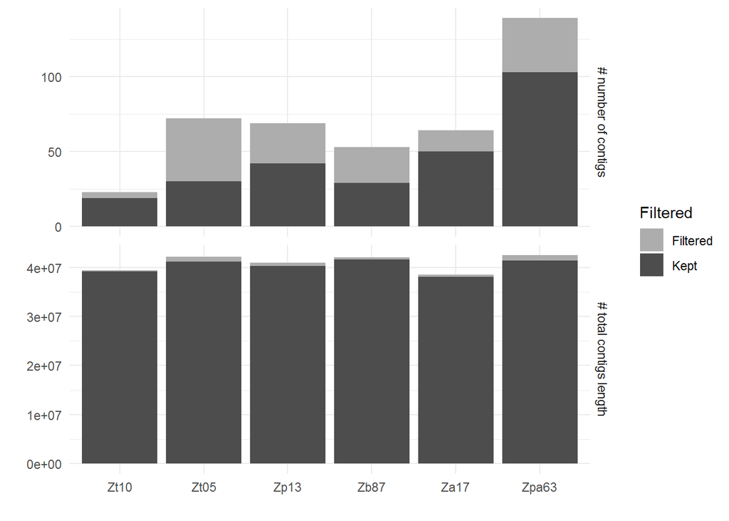

```r
differences_count = differences[,c(1, 2, 4, 5)]
differences_count = gather(differences_count, "After", "Difference",
                           key = "Filtered", value = "Value")
differences_count[differences_count == "After"] = "Kept"
differences_count[differences_count == "Difference"] = "Filtered"
ggplot(data = differences_count, aes(Sample,
                                     as.numeric(Value),
                                     fill = Filtered)) +
  geom_col(position = "stack") + facet_grid(Statistic~., scales="free_y") +
  labs(x = " ",
       y = " ") +
  scale_fill_manual(values = c("grey68", "gray30")) +
  theme_minimal()
```

### Completeness of the assemblies and mitochondrial sequences

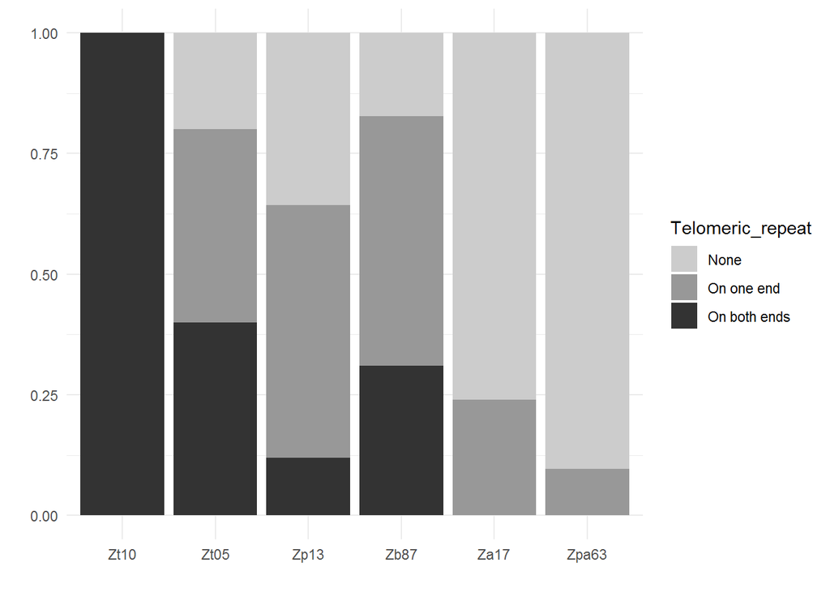

```r
results = list()
for (sample in our_samples) {

#Gather data from tables generated previously
file_names = list.files(ASpolished_dir,
           pattern = paste0(sample, "*"))
file_name = file_names[grep(pattern = AS_per_contig_suffix,
                            x = file_names)]
per_contig = read.table(paste0(ASpolished_dir, file_name), header = TRUE, sep = "\t")
per_contig$Telomeric_repeat = ifelse(per_contig$Telomeric_repeats_start == "Yes" &
                                  per_contig$Telomeric_repeats_end == "Yes",
                                   "On both ends",
                           ifelse (per_contig$Telomeric_repeats_start == "Yes" |
                                   per_contig$Telomeric_repeats_end == "Yes",
                                   "On one end", "None"))
per_contig = per_contig[per_contig$Filtered_based_on_coverage == "pass",]
per_contig$Sample = sample
results[[sample]] = per_contig
}

results_assembly = bind_rows(results)
summary = results_assembly %>%
  group_by(Sample) %>%
  count(Telomeric_repeat)

#Reorder for plot
summary$Sample = factor(summary$Sample,
                        levels = our_samples)

summary$Telomeric_repeat = factor(summary$Telomeric_repeat,
                                  levels = c("None",
                                             "On one end",
                                             "On both ends"))

#Plot
ggplot(summary, aes(x=Sample, y=n, fill = Telomeric_repeat)) +
  geom_col(position = "fill") +
  labs(x = " ",
       y = " ") +
  scale_fill_grey(start = 0.8, end = 0.2) +
  theme_minimal()
```

```r
kable(summary %>%
  spread(key = Telomeric_repeat, value = n, fill = 0))
```

| Sample | None | On one end | On both ends |
| --- | --- | --- | --- |
| Zt10 | 0 | 0 | 19 |
| Zt05 | 6 | 12 | 12 |
| Zp13 | 15 | 22 | 5 |
| Zb87 | 5 | 15 | 9 |
| Za17 | 38 | 12 | 0 |
| Zpa63 | 93 | 10 | 0 |

## Orthologs

In order to identify the different orthologs in the different genomes, we have used the software PoFF, which is based on the Proteinortho tool. Proteinortho implements a version of the reciprocal best alignment, adapted to use on large datasets. PoFF builds on these results to include synteny information in a systematic way, which leads to improvement of orthologs detection in closely related genomes. Because we know that synteny is quite conserved between our genomes, we can use this method and expect improvement over not taking this layer of information into account. This seemed confirmed by our comparison of the results of PoFF and OrthoFinder, which created many large families, instead of identifying orthologs more finely.

### Inter-specific comparison

First, we will define which orthologs are found only in some groups: only in *Zymoseptoria* genomes, only in *Z. tritici* genomes or only in some strains. The meaning of this last category is different for *Z. tritici* and for the other Zymoseptoria species. Because there is only one strain for the other Zymoseptoria species, the genes which are specific to these strains can’t be distinguished from the species-specific genes. We considered these genes as belonging to the “species-specific” category.

```r
ortho = read_tsv(orthologs_file)
colnames(ortho) = sub(".faa", "", colnames(ortho))
colnames(ortho) = sub("# ", "", colnames(ortho))
ortho$Orthogroup = paste0("OG_", row.names(ortho))

## Specific genes

#Identifying the genes specific to Zymoseptoria
ortho_tab = as.data.frame(ortho[, c(4:11)])
ortho$Specific_Zymo = ifelse(test = ortho$CB0940 == "*", "True", "False")
print(paste0("The number of genes found specifically in Zymoseptoria genomes is ",
             nrow(ortho_tab[ortho_tab$CB0940 == "*", ])))
```

[1] “The number of genes found specifically in Zymoseptoria genomes is 9955”

```r
#Identifying the genes specific to Z. tritici
Zt_spe = ortho[ortho$Species <= 3, c(1, 9:12)]
Zt_spe$SUM = apply(Zt_spe, 1, function(x) sum(x[2:4] != "*"))
Zt_spe = Zt_spe[Zt_spe$SUM == Zt_spe$Species,]
Zt_spe$Specific_Zt = "True"

ortho = left_join(ortho, Zt_spe[, c(1, 5, 7)],
                  by = c("Orthogroup", "Species"))
ortho$Specific_Zt[is.na(ortho$Specific_Zt)] = "False"

print(paste0("The number of genes found specifically in Z. tritici genomes is ",
             nrow(Zt_spe)))
```

[1] “The number of genes found specifically in Z. tritici genomes is 2476”

```r
#Identifying the genes specific to each strain
strain_names = colnames(ortho[, c(4:11)])

get_strain_name = function(x) {
  if (x[["Species"]] == 1) {
    index = which(x[c(4:11)] != "*")
    return(strain_names[index])
  } else {return('False')}
}
ortho$Specific_strain = apply(ortho, 1, function(x) get_strain_name(x))
kable(table(ortho$Specific_strain))
```

| Var1 | Freq |
| --- | --- |
| CB0940 | 4104 |
| False | 13081 |
| Za17 | 804 |
| Zb87 | 996 |
| Zp13 | 552 |
| Zpa63 | 962 |
| Zt05 | 659 |
| Zt09 | 792 |
| Zt10 | 391 |

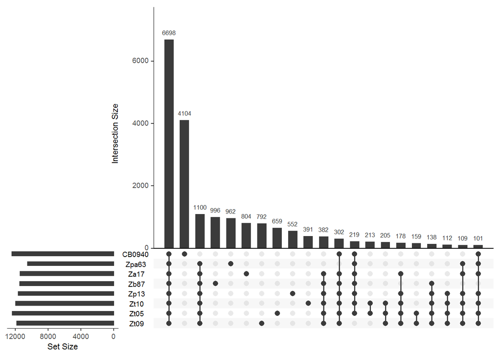

```r
## Common genes

ortho$Common_all = ifelse(ortho$Species == "8",
                          "True",
                          "False")

ortho$Common_Zymo = ifelse(ortho$Species == "7" & ortho$Specific_Zymo == "True",
                           "True",
                           "False")
ortho$Common_Zt = ifelse(ortho$Species == "3" & ortho$Specific_Zt == "True",
                           "True",
                           "False")


##Upset plot
ortho_tab[ortho_tab != "*"] = 1
ortho_tab[ortho_tab == "*"] = 0
ortho_tab[] <- lapply(ortho_tab, function(x) as.numeric(as.character(x)))
upset(ortho_tab, nsets = 8,
      nintersects = 21,
      order.by="freq",
      sets = c("Zt09", "Zt05", "Zt10",
               "Zp13", "Zb87", "Za17",
               "Zpa63", "CB0940"),
      keep.order = TRUE)
```

```r
##Data formatting
#Preparing the data to merge later with the rest of the predictions
ortho_tidy = gather(ortho[, c(4:ncol(ortho))],
               "Zt09", "Zt05", "Zt10",
               "Zp13", "Zb87", "Za17",
               "Zpa63", "CB0940",
               key = "Sample", value = "Protein_ID")

#Adding a column with the paralogs
finds_para <- function(x) {
  temp = grepl(",", x["Protein_ID"], fixed=TRUE)
  if (temp){
    return ("True")
  } else {return("False")}
}
ortho_tidy$is_para = apply(ortho_tidy, 1, function(x) finds_para(x))

ortho_tidy = ortho_tidy %>%
    mutate(Protein_ID = strsplit(as.character(ortho_tidy$Protein_ID), ",")) %>%
    unnest(Protein_ID)
```

To complement and graphically summarize the upset plot above, we create a doughnut plot with the number of genes belonging to different specificity levels: strain-specific genes, species-specific genes, genus-specific genes and finally genes shared by all genomes.

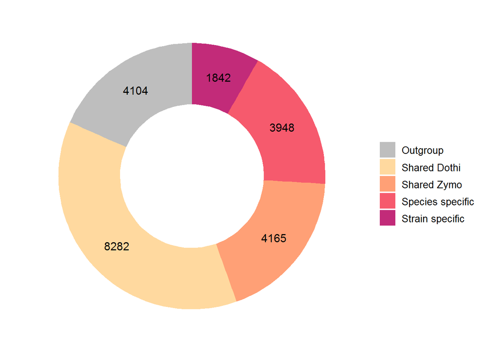

```r
ortho_dough = distinct(ortho_tidy[,c(1:4)])

#Classifying the orthologs
colors_doughnut = c("grey", rev(q4[c(2:5)]))
ortho_dough$Specificity2 = ifelse(ortho_dough$Specific_strain == "CB0940",
                                  "Outgroup",
                                  ifelse(ortho_dough$Specific_strain %in% our_samples[c(3:6)],
                                         "Species specific",
                                  ifelse(ortho_dough$Specific_strain %in% c("Zt10", "Zt09", "Zt05"),
                                           "Strain specific",
                                  ifelse(ortho_dough$Specific_Zt,
                                                  "Species specific",
                                  ifelse(ortho_dough$Specific_Zymo,
                                         "Shared Zymo",
                                           "Shared Dothi")))))
temp = as.data.frame(table(ortho_dough$Specificity2))

p <- ggplot(temp, aes(x=2, y=Freq, fill=Var1)) +
  geom_bar(stat="identity") +
  xlim(0.5, 2.5) +
  coord_polar(theta = "y") +
  labs(x=NULL, y=NULL) +
  labs(fill="") +
  scale_fill_manual(values = colors_doughnut) +
  theme_bw() +
  theme(plot.title = element_text(face="bold",family=c("sans"),size=15),
        legend.text=element_text(size=10),
        axis.ticks=element_blank(),
        axis.text=element_blank(),
        axis.title=element_blank(),
        panel.grid=element_blank(),
        panel.border=element_blank()) +
  geom_text(aes(label = Freq),
               position = position_stack(vjust = 0.5), size = 4)
p
```

### Intra-specific comparison: Z. tritici

After looking at the shared orthologs while including all our genomes, i.e. an inter-species comparison, we decided to also check the orthologs intra-species. The Venn diagram produced here is only including the 3 strains of *Z. tritici*.

```
## [1] 1
```

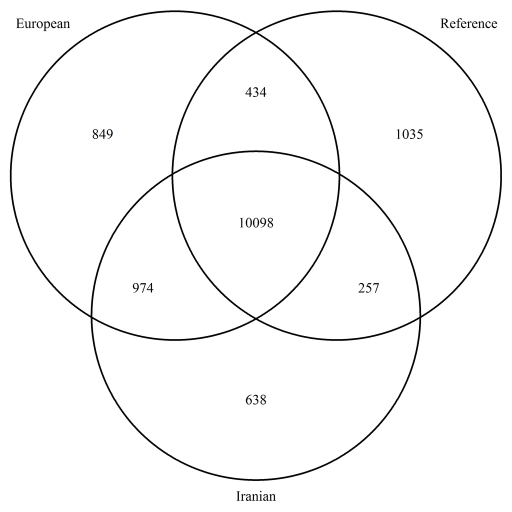

```r
Zt05_ortho = ortho %>%
  filter(Zt05 != "*") %>%
  pull(Orthogroup)
Zt09_ortho = ortho %>%
  filter(Zt09 != "*") %>%
  pull(Orthogroup)
Zt10_ortho = ortho %>%
  filter(Zt10 != "*") %>%
  pull(Orthogroup)

venn.diagram(
  x = list(Zt05_ortho, Zt09_ortho, Zt10_ortho),
  category.names = c("European" , "Reference" , "Iranian"),
  filename = paste0(figures_dir, "Venn_diagram_for_Zt_only.png"), imagetype = "png")
```

Here, we noticed that the genes identified as orphan (i.e. strain specific) and accessory (i.e. shared by only two strains out of the three), are fewer when including the wild-grasses infecting pathogen genomes. Zymoseptoria tritici thus shares some of its accessory genome with its sister-species.

### Enrichment analysis per contig

Now, that we have an idea about the amount of genes belonging to these specificity levels, we wanted to know if some contigs were enriched in highly specific genes (i.e. strain or species specific). This is especially relevant in Zymoseptoria since *Z. tritici* is well known to be compartmentalized with distinct accessory chromosomes and core chromosomes. Note that, as previously mentioned, there are several isolates of Z. tritici (Zt09, Zt05 and Zt10) but only one of the other species. This explain the higher number of calculations done below for the Z. tritici strains.

```r
n_simulations = 1000

#Function to compare the observed values to the randomly simulated values
count_low_high = function(x, y, z){
  if (y == "Higher"){
    return (sum(as.numeric(x[c(3:z)]) > as.numeric(x[2])))}
  else if (y == "Lower") {
   return (sum(as.numeric(x[c(3:z)]) < as.numeric(x[2])))}
  else if (y == "Equal") {
    return (sum(as.numeric(x[c(3:z)]) == as.numeric(x[2])))}
  }

#For all samples, we gather the observed data
for (sample in samples){
  print(sample)
if (sample == "Zt09") {
  temp = ortho %>%
  filter((!!as.name(sample)) != "*") %>%
  separate(sample, sep = "_", into = c("Sample", "Contig_name", "Gene_nb")) %>%
  mutate(Contig = paste0("Zt09_", Contig_name))
} else {
temp = ortho %>%
  filter((!!as.name(sample)) != "*") %>%
  separate(sample, sep = "\\.", into = c("Contig", "Gene_nb"))  }

table_enrichment  = as.data.frame(table(temp %>%
               filter(Specific_strain == sample) %>%
               select(Contig)))

colnames(table_enrichment) = c("Contig", "Observed_count")

#Time for the random simulations
for (i in c(1:n_simulations)) {
temp2 <- transform( temp, Specific_strain = base::sample(Specific_strain) )
sim = as.data.frame(table(temp2 %>%
               filter(Specific_strain == sample) %>%
               select(Contig)))
colnames(sim) = c("Contig", paste0("Simulated_count_", i))
table_enrichment = full_join(table_enrichment, sim, by = "Contig")
}

table_enrichment[is.na(table_enrichment)] = 0

until = ncol(table_enrichment)
table_enrichment$Higher =apply(table_enrichment, 1, function(x) count_low_high(x, "Higher", until))
table_enrichment$Equal =apply(table_enrichment, 1, function(x) count_low_high(x, "Equal", until))
table_enrichment$Lower =apply(table_enrichment, 1, function(x) count_low_high(x, "Lower", until))

table_enrichment %>% select(Contig, Observed_count, Higher, Equal, Lower) %>%
  write_tsv(path = paste0(specificity_output_dir,
                          sample, "_strain_specific_per_chr.tsv"))
}


#As there are several genomes of Z. tritici, we can look at different gene categories
#For genes which are specific of Zt but are not strain-specific
for (sample in c("Zt09", "Zt05", "Zt10")){
  if (sample == "Zt09") {
  temp = ortho %>%
  filter((!!as.name(sample)) != "*") %>%
  separate(sample, sep = "_", into = c("Sample", "Contig_name", "Gene_nb")) %>%
  mutate(Contig = paste0("Zt09_", Contig_name))
} else {
temp = ortho %>%
  filter((!!as.name(sample)) != "*") %>%
  separate(sample, sep = "\\.", into = c("Contig", "Gene_nb"))  }

table_enrichment  = as.data.frame(table(temp %>%
               filter(Specific_Zt == "True") %>%
               filter(Specific_strain != sample) %>%
               select(Contig)))
colnames(table_enrichment) = c("Contig", "Observed_count")

for (i in c(1:n_simulations)) {
temp2 <- transform( temp, Specific_Zt = base::sample(Specific_Zt) )
sim = as.data.frame(table(temp2 %>%
               filter(Specific_Zt == "True") %>%
               select(Contig)))
colnames(sim) = c("Contig", paste0("Simulated_count_", i))
table_enrichment = full_join(table_enrichment, sim, by = "Contig")
}

table_enrichment[is.na(table_enrichment)] = 0

until = ncol(table_enrichment)
table_enrichment$Higher =apply(table_enrichment, 1, function(x) count_low_high(x, "Higher", until))
table_enrichment$Equal =apply(table_enrichment, 1, function(x) count_low_high(x, "Equal", until))
table_enrichment$Lower =apply(table_enrichment, 1, function(x) count_low_high(x, "Lower", until))

table_enrichment %>% select(Contig, Observed_count, Higher, Equal, Lower) %>%
  write_tsv(path = paste0(specificity_output_dir,
                          sample, "_species_specific_not_strain_spe_per_chr.tsv"))
}


#For Zt specificity
for (sample in c("Zt09", "Zt05", "Zt10")){
  if (sample == "Zt09") {
  temp = ortho %>%
  filter((!!as.name(sample)) != "*") %>%
  separate(sample, sep = "_", into = c("Sample", "Contig_name", "Gene_nb")) %>%
  mutate(Contig = paste0("Zt09_", Contig_name))
} else {
temp = ortho %>%
  filter((!!as.name(sample)) != "*") %>%
  separate(sample, sep = "\\.", into = c("Contig", "Gene_nb"))  }

table_enrichment  = as.data.frame(table(temp %>%
               filter(Specific_Zt == "True") %>%
               select(Contig)))
colnames(table_enrichment) = c("Contig", "Observed_count")

for (i in c(1:n_simulations)) {
temp2 <- transform( temp, Specific_Zt = base::sample(Specific_Zt) )
sim = as.data.frame(table(temp2 %>%
               filter(Specific_Zt == "True") %>%
               select(Contig)))
colnames(sim) = c("Contig", paste0("Simulated_count_", i))
table_enrichment = full_join(table_enrichment, sim, by = "Contig")
}

table_enrichment[is.na(table_enrichment)] = 0

until = ncol(table_enrichment)
table_enrichment$Higher =apply(table_enrichment, 1, function(x) count_low_high(x, "Higher", until))
table_enrichment$Equal =apply(table_enrichment, 1, function(x) count_low_high(x, "Equal", until))
table_enrichment$Lower =apply(table_enrichment, 1, function(x) count_low_high(x, "Lower", until))

table_enrichment %>% select(Contig, Observed_count, Higher, Equal, Lower) %>%
  write_tsv(path = paste0(specificity_output_dir,
                          sample, "_species_specific_per_chr.tsv"))
}
```

## Functionnal annotations

### Custom pipeline: cellular location, secretion and effectors

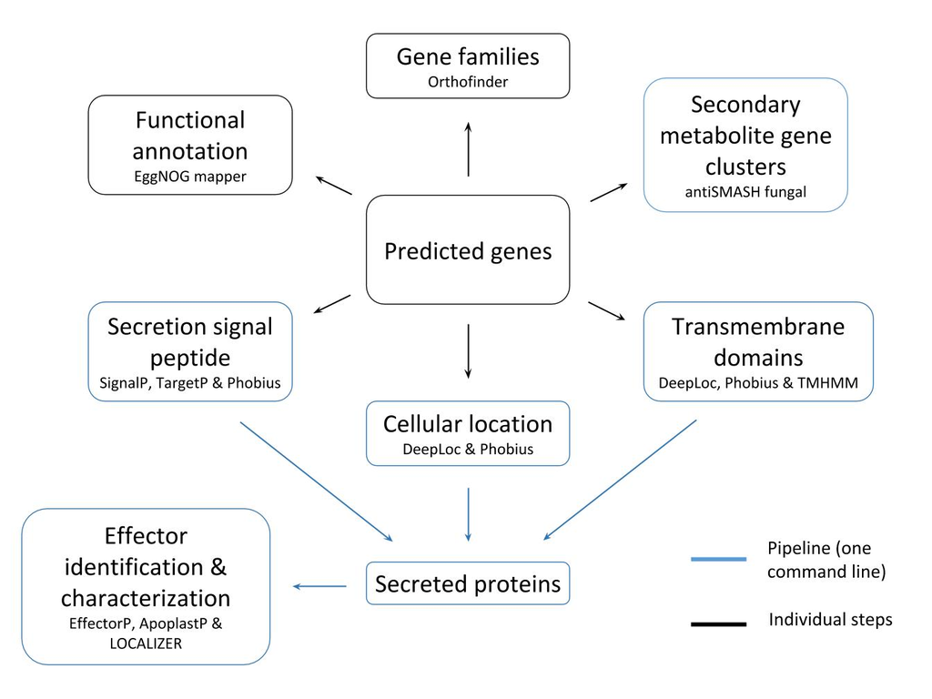

Workflow for functionnal annotations. The bubbles outlined in blue represent the steps which are included in our custom pipelines: we have created scripts which allow all of these steps to be launched using the predicted genes and the assembled genome with only one command line. The bubbles outlined in black are predictions steps which we ran but which are not included in our automatic pipeline. The software used for each prediction step are indicated in the bubbles.

Here, the tables resulting from our custom pipeline (outlined in blue in the figure) are parsed in order to extract the information necessary to create the figures. In the following chunk, I gather the numbers of predictions per sample for:

- secreted proteins
- effectors
- genes included in metabolite gene clusters

The count of predicted effectors and genes belonging to a secondary metabolite gene cluster are straightforward and just extracted from the table. In order to define whether a gene product is expected to be secreted, however, we look at several columns and conditions:

- a secretion peptide must have been predicted
- the predicted cellular location must be extracellular
- no transmembrane domain must be identified in the sequence

From the same files, I also gather the cellular location predictions.

```r
results=list()

for (sample in samples_out) {

  #Import table with predictions from the pipeline
  prediction_files = list.files(Annot_dir,
             pattern = paste0(sample, "_*"))
  prediction_file = prediction_files[grepl(pattern = predictions_file_suffix,
                              x = prediction_files, fixed = TRUE)]
  predictions = read_tsv(paste0(Annot_dir, prediction_file),
                         na = c("", "NA", "-"), guess_max = 10000)
  predictions$Sample = sample

  #Import table containing info about contig and position of genes
  bed_files = list.files(Annot_dir,
             pattern = paste0(sample, "_*"))

  bed_file = bed_files[grepl(pattern = bed_file_suffix,
                              x = bed_files, fixed = TRUE)]

  bed_table = read_tsv(paste0(Annot_dir, bed_file), col_names = FALSE)[,c(4, 1, 2, 3, 6)]
  colnames(bed_table) = c("#Protein_ID", "Contig", "Start", "End", "Strand")
  bed_table$Contig = gsub('contig_', "", bed_table$Contig)


  results[[sample]] = as.data.frame(full_join(bed_table, predictions, by="#Protein_ID"))

}

#Adding all tables together
#And concatenating with orthogroups
large_table = do.call(bind_rows, results)
colnames(large_table) = gsub("#", "", colnames(large_table))
large_table = left_join(large_table, ortho_tidy,
                        by = c("Protein_ID", "Sample"))


#Secreted/MGC/effectors
results=list()
large_table_cell_loc = list()


for (sample in samples_out) {
  predictions = large_table[which(large_table$Sample == sample),]


  #The table created for each sample is parsed and the number of gene product
  # from each prediction of interest is counted.
  temp_secreted = nrow(filter(predictions,
                Secretion == "Secreted" &
                  Transmembrane =="Not_TM" &
                  Cell_location == "Extracellular"))

  temp_effectors = nrow(filter(predictions,
                Effector == "Effector"))

  temp_cluster = as.integer(summarise_at(predictions,
                                         vars(starts_with("cluster")),
                                         funs(sum(!is.na(.)))))


  #The results from the counting is stored in the results list.
  results[[sample]]=list("Sample" = sample, "Secreted" = temp_secreted,
                 "Effectors" = temp_effectors, "MGC" = temp_cluster)

  #Additionnally, the cell compartments predicted for the gene products are
  #summarized and stored in the cell loc list.
  Cell_localization = count(x=predictions, Cell_compartment = Cell_location)
  Cell_localization$Sample = sample
  large_table_cell_loc[[sample]] = Cell_localization

}

#Data from all the samples is finally gathered into one object.
summary_tidy = gather(data = bind_rows(results), "Secreted", "Effectors", "MGC",
               key = "Classe", value = "Count")

cellLoc_tidy = bind_rows(large_table_cell_loc)
```

First, I am using the cellular location predictions to make a bubble chart in which the area of the bubble reflects the number of gene product.

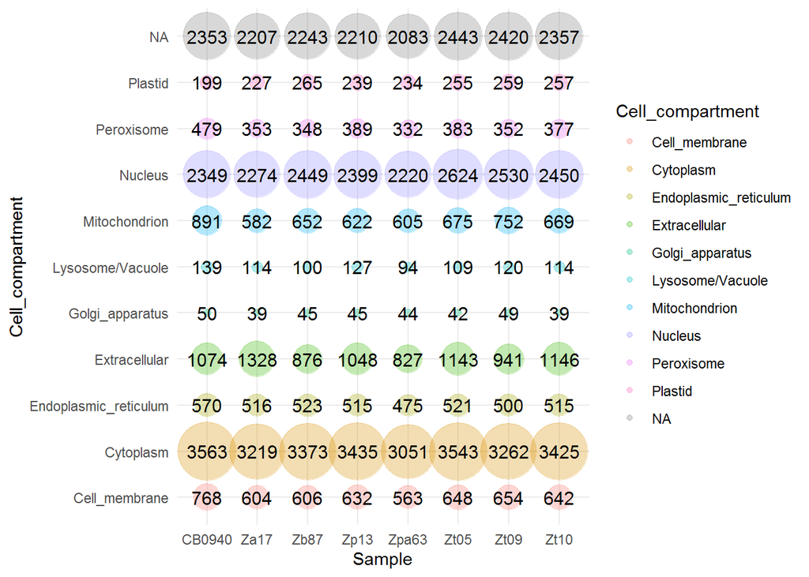

```r
cellLoc_tidy$radius <- sqrt( cellLoc_tidy$n / (pi*4) )

c = ggplot(cellLoc_tidy, aes(Sample, Cell_compartment)) +
  geom_point(aes(size=radius, color = Cell_compartment), alpha=0.3)+
  geom_text(aes(label=n), size=4) +
  scale_size_identity()

c + theme_minimal()
```

I use the summarized table in the previous chunks which includes numbers of genes predicted to be in clusters, secreted or effector.

### CAZyme detection

```r
results = list()
for (sample in samples_out) {
  file_names = list.files(Annot_dir,
           pattern = paste0(sample, "_*"))

  file_name = file_names[grepl(pattern = CAZymes_file_suffix,
                            x = file_names, fixed = TRUE)]
predictions = read_tsv(paste0(Annot_dir, file_name), na = c("", "NA", "-", "N"))
predictions$Sample = sample
results[[sample]] = predictions
predictions = predictions[predictions$`#ofTools` >= 2, ]

summary_tidy = add_row(summary_tidy,
                       Sample = sample,
                       Classe = "CAZymes",
                       Count = nrow(predictions))
}

CAZymes = bind_rows(results) %>%
  separate("HMMER", c("HMMER1", "HMMER2"), sep = "\\+") %>%
  separate("Hotpep", c("Hotpep1", "Hotpep2"), sep = "\\+")
CAZymes$CAZyme = ifelse(CAZymes$`#ofTools` >= 2,
                        "CAZyme",
                        "Possible CAZyme")

CAZymes$HMMER1 = str_replace(CAZymes$HMMER1, "\\([0-9]+-[0-9]+\\)", "")
CAZymes$HMMER2 = str_replace(CAZymes$HMMER2, "\\([0-9]+-[0-9]+\\)", "")
temp = unlist(CAZymes[1, c(2:6)])

get_most_frequent = function(x) {
  temp = sort(table(x),decreasing=TRUE)
  if (length(temp) == 1) {
    return(names(temp))
  } else if (temp[1] == 1) {
    return("NA")
  }
  else if (temp[1] > temp[2]) {
   return(names(temp[1]))}
  else {
    return(paste(names(temp[1]), names(temp[2]), sep = ", "))
  }
}

CAZymes$CAZyme_family = apply(CAZymes[,c(2:6)], 1, function(x) get_most_frequent(x))
colnames(CAZymes)[1] = "Protein_ID"
large_table = left_join(x = large_table, y = CAZymes[, c("Protein_ID", "Sample", "CAZyme", "CAZyme_family")], by =c("Protein_ID", "Sample"))

classes = c("CE", "GH", "PL", "AA", "CBM", "GT")
for (classe in classes) {
  tempF1 = function(x, y) {
    return(sum(grepl(x, y)))
  }
  temp = CAZymes %>%
    group_by(Sample) %>%
    summarise(classe = tempF1(classe,CAZyme_family))
  if (classe == classes[[1]]) {
    CAZ_per_sample = temp
  } else {
    CAZ_per_sample = full_join(CAZ_per_sample, temp, by = "Sample")
  }
}

colnames(CAZ_per_sample) = c("Sample", classes)
kable(CAZ_per_sample)
```

| Sample | CE | GH | PL | AA | CBM | GT |
| --- | --- | --- | --- | --- | --- | --- |
| CB0940 | 77 | 268 | 5 | 96 | 23 | 143 |
| Za17 | 61 | 211 | 4 | 57 | 26 | 122 |
| Zb87 | 65 | 218 | 3 | 59 | 25 | 127 |
| Zp13 | 62 | 226 | 2 | 61 | 25 | 126 |
| Zpa63 | 52 | 200 | 2 | 47 | 23 | 124 |
| Zt05 | 63 | 227 | 3 | 57 | 25 | 130 |
| Zt09 | 62 | 219 | 3 | 59 | 24 | 124 |
| Zt10 | 65 | 226 | 2 | 56 | 26 | 127 |

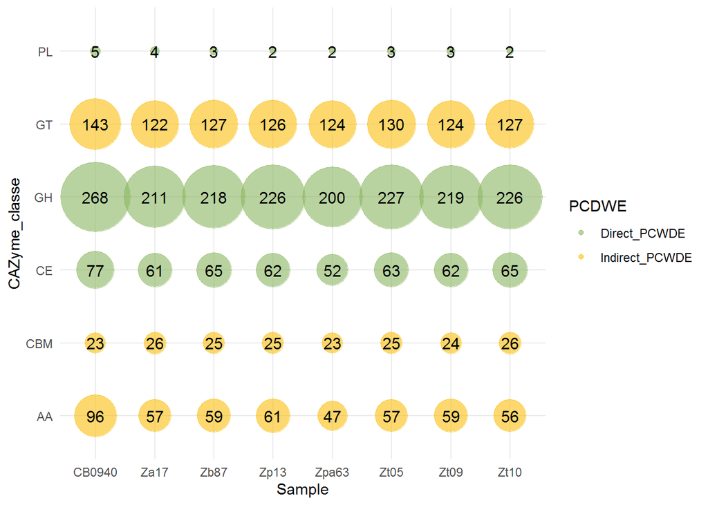

```r
CAZyme_tidy = gather(CAZ_per_sample, classes, key = "CAZyme_classe", value = "Count")
CAZyme_tidy$radius = sqrt( CAZyme_tidy$Count / pi )
CAZyme_tidy$PCDWE = ifelse(CAZyme_tidy$CAZyme_classe %in% c("CE", "GH", "PL"), "Direct_PCWDE", "Indirect_PCWDE")

#Bubble plot for classes of CAZyme per studied genome
c = ggplot(CAZyme_tidy, aes(Sample, CAZyme_classe)) +
  geom_point(aes(size=radius*2.5, color = PCDWE), alpha=0.6)+
  geom_text(aes(label=Count), size=4) +
  scale_size_identity()

c + theme_minimal() + scale_color_manual(values=my_colors)
```

We create a plot to summarize the results of the main predictions linked to pathogenicity: effectors, secondary metabolite gene clusters and CAZymes.

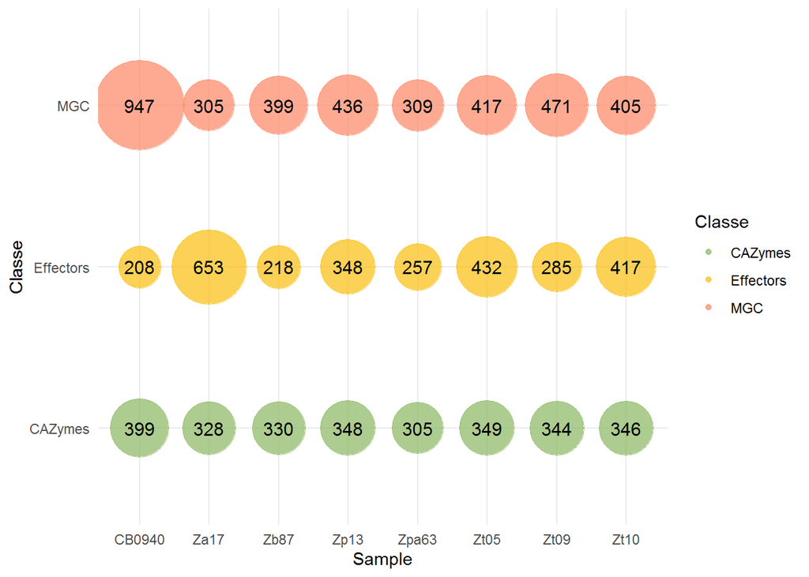

```r
summary_tidy$radius <- sqrt( summary_tidy$Count / pi )

#I had initially represented the secreted proteins as one of the bubble lines
#But it made little sense, so I removed them.
c = ggplot(summary_tidy[summary_tidy$Classe != "Secreted",], aes(Sample, Classe)) +
  geom_point(aes(size=radius*1.5, color = Classe), alpha=0.7)+
  geom_text(aes(label=Count), size=4) +
  scale_size_identity()

c + theme_minimal() + scale_color_manual(values=my_colors)
```

### BGC

```r
clusters_ortho = large_table[large_table$`Cluster(nb, function)` != '-', "Orthogroup"]

temp = large_table[which(large_table$Orthogroup %in% clusters_ortho), c("Sample", "Cluster(nb, function)", "Orthogroup")]
colnames(temp) = c("Sample", "Cluster", "Orthogroup")
temp$Cluster[is.na(temp$Cluster)] = "Not_cluster"

clusters = temp[!duplicated(paste0(temp$Sample, temp$Orthogroup)),] %>%
  spread(Sample, Cluster)
write.table(x = clusters, file = paste0(Annot_dir, "Gene_clusters.txt"),
            sep = "\t", quote = FALSE, row.names = FALSE)
```

Of note: in between these chunks, I had to manually add names for the common clusters.

```r
clusters = read_tsv(file =paste0(Annot_dir, "Gene_clusters_manual.txt"))
Named_clusters = clusters[!is.na(clusters$Consensus_name),]
cluster_functions = na.omit(distinct(clusters[, c("Consensus_name", "Function")]))


temp = Named_clusters %>%
      gather("Zt09", "Zt05", "Zt10",
                "Zp13", "Zb87", "Za17",
                "Zpa63", "CB0940",
             key = "Sample", value = "Clust_name")
temp = temp[,c("Sample", "Orthogroup", "Consensus_name")]
colnames(temp) = c("Sample", "Orthogroup", "Inter_species_cluster_name")

large_table = left_join(large_table, temp, by=c("Sample", "Orthogroup"))


is_not_found <- function(x) {
  return(sum(!is.na(x)))
}
is_in_cluster <- function(x) {
  t = grepl(";", x, fixed = TRUE)
  return(sum(t))
}
Named_clusters2 = Named_clusters %>%
  group_by(Consensus_name) %>%
  summarize_all(list(is_not_found, is_in_cluster))
Named_clusters2 = Named_clusters2[, c(1:10, 13:20)]
Named_clusters2 = full_join(Named_clusters2, cluster_functions, by =c("Consensus_name"))
write.table(x = Named_clusters2,
            file = paste0(Annot_dir, "Gene_clusters_manual_summary.txt"),
            sep = "\t", quote = FALSE, row.names = FALSE)



#Per cluster, genes with an ortholog
temp = as.data.frame(
        Named_clusters[,c(1:10)] %>%
        group_by(Consensus_name) %>%
       summarize_all(is_not_found))

temp = full_join(temp, cluster_functions, by =c("Consensus_name"))
kable(temp, caption = "Per cluster, count of genes for which an ortholog was found in this genome")
```

Per cluster, count of genes for which an ortholog was found in this genome

| Consensus_name | Orthogroup | CB0940 | Za17 | Zb87 | Zp13 | Zpa63 | Zt05 | Zt09 | Zt10 | Function |
| --- | --- | --- | --- | --- | --- | --- | --- | --- | --- | --- |
| Cluster_1 | 30 | 14 | 19 | 19 | 19 | 21 | 18 | 17 | 16 | other |
| Cluster_10 | 25 | 13 | 17 | 21 | 17 | 18 | 19 | 19 | 19 | nrps |
| Cluster_11 | 23 | 8 | 6 | 4 | 5 | 5 | 19 | 20 | 17 | nrps |
| Cluster_12 | 35 | 17 | 26 | 24 | 24 | 21 | 25 | 25 | 25 | terpene |
| Cluster_13 | 18 | 7 | 12 | 14 | 15 | 13 | 14 | 13 | 12 | nrps |
| Cluster_14 | 27 | 12 | 22 | 20 | 21 | 20 | 20 | 20 | 20 | t1pks |
| Cluster_15 | 22 | 19 | 21 | 20 | 21 | 21 | 21 | 20 | 21 | other |
| Cluster_16 | 28 | 12 | 18 | 15 | 20 | 11 | 20 | 24 | 16 | t1pks |
| Cluster_17 | 35 | 16 | 29 | 20 | 24 | 21 | 31 | 32 | 30 | nrps |
| Cluster_18 | 24 | 17 | 21 | 20 | 21 | 16 | 23 | 22 | 22 | nrps |
| Cluster_19 | 38 | 14 | 20 | 30 | 18 | 18 | 19 | 17 | 18 | nrps |
| Cluster_2 | 12 | 7 | 9 | 10 | 8 | 7 | 10 | 9 | 10 | siderophore |
| Cluster_20 | 17 | 4 | 6 | 14 | 15 | 5 | 15 | 15 | 15 | t1pks |
| Cluster_21 | 22 | 12 | 16 | 19 | 14 | 11 | 14 | 13 | 17 | nrps |
| Cluster_22 | 21 | 11 | 14 | 17 | 12 | 13 | 18 | 15 | 18 | other |
| Cluster_23 | 15 | 10 | 14 | 10 | 13 | 9 | 14 | 11 | 14 | t1pks |
| Cluster_24 | 41 | 28 | 36 | 35 | 35 | 29 | 36 | 32 | 36 | t1pks |
| Cluster_25 | 29 | 10 | 15 | 17 | 22 | 18 | 26 | 22 | 22 | t1pks |
| Cluster_26 | 14 | 6 | 6 | 8 | 12 | 6 | 11 | 12 | 7 | other |
| Cluster_27 | 21 | 9 | 17 | 14 | 18 | 16 | 18 | 16 | 17 | other |
| Cluster_28 | 28 | 21 | 23 | 24 | 25 | 23 | 27 | 24 | 25 | t1pks |
| Cluster_29 | 35 | 20 | 24 | 26 | 27 | 23 | 27 | 29 | 27 | other |
| Cluster_3 | 14 | 11 | 12 | 10 | 11 | 10 | 12 | 12 | 13 | terpene |
| Cluster_30 | 18 | 7 | 11 | 12 | 14 | 6 | 15 | 18 | 16 | nrps |
| Cluster_31 | 24 | 14 | 19 | 18 | 17 | 15 | 18 | 12 | 18 | other |
| Cluster_32 | 27 | 15 | 16 | 21 | 22 | 15 | 21 | 20 | 22 | t1pks |
| Cluster_33 | 16 | 9 | 7 | 12 | 9 | 6 | 9 | 11 | 11 | terpene |
| Cluster_34 | 23 | 5 | 12 | 14 | 17 | 14 | 18 | 11 | 16 | nrps |
| Cluster_35 | 8 | 6 | 8 | 4 | 7 | 3 | 4 | 4 | 4 | nrps |
| Cluster_36 | 16 | 9 | 10 | 9 | 16 | 9 | 8 | 8 | 9 | nrps |
| Cluster_37 | 9 | 4 | 8 | 1 | 8 | 1 | 0 | 0 | 0 | t1pks |
| Cluster_38 | 5 | 2 | 3 | 5 | 2 | 4 | 3 | 2 | 3 | nrps |
| Cluster_39 | 17 | 7 | 8 | 11 | 10 | 12 | 9 | 6 | 9 | t1pks |
| Cluster_4 | 24 | 15 | 17 | 18 | 17 | 22 | 17 | 16 | 17 | terpene |
| Cluster_40 | 12 | 6 | 6 | 12 | 6 | 4 | 7 | 6 | 7 | t1pks |
| Cluster_41 | 10 | 7 | 6 | 10 | 5 | 9 | 4 | 5 | 5 | terpene |
| Cluster_42 | 14 | 3 | 2 | 14 | 1 | 0 | 0 | 0 | 0 | nrps |
| Cluster_43 | 17 | 10 | 14 | 12 | 13 | 13 | 13 | 11 | 13 | t1pks |
| Cluster_44 | 10 | 8 | 10 | 0 | 1 | 1 | 0 | 0 | 0 | t1pks |
| Cluster_45 | 10 | 4 | 7 | 7 | 7 | 10 | 9 | 5 | 9 | nrps |
| Cluster_46 | 12 | 2 | 6 | 7 | 7 | 12 | 6 | 6 | 6 | t3pks |
| Cluster_5 | 25 | 8 | 18 | 11 | 16 | 11 | 18 | 17 | 15 | t3pks |
| Cluster_6 | 29 | 10 | 12 | 22 | 22 | 13 | 21 | 20 | 21 | nrps |
| Cluster_7 | 29 | 18 | 22 | 28 | 22 | 21 | 22 | 24 | 27 | t1pks |
| Cluster_8 | 15 | 8 | 4 | 13 | 5 | 12 | 3 | 14 | 4 | t1pks |
| Cluster_9 | 26 | 8 | 7 | 22 | 21 | 8 | 22 | 22 | 8 | t1pks-nrps |

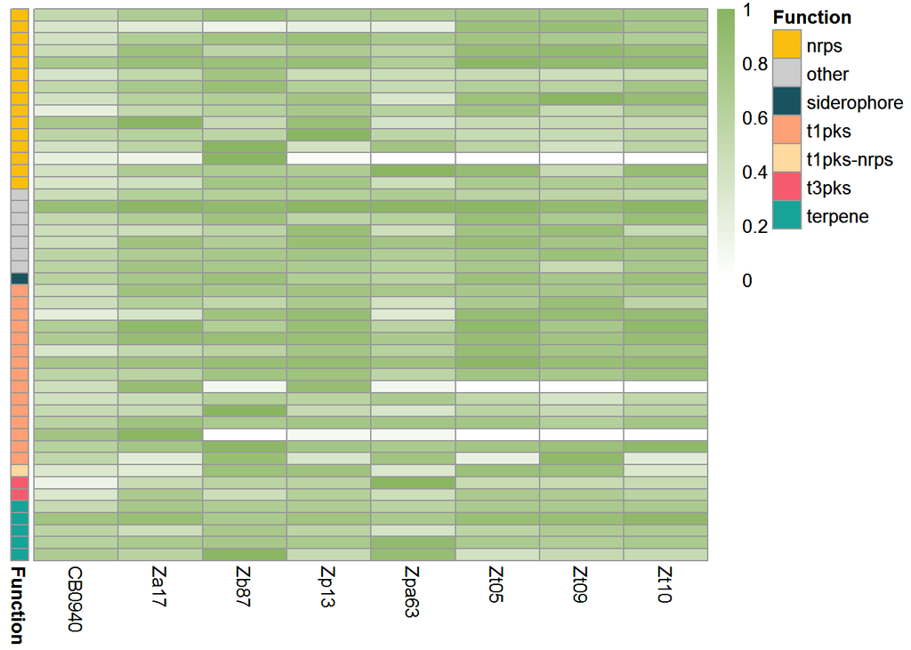

```r
temp = temp[order(temp$Function),]
ortho_found = colSums(temp[, c(3:10)])


#Pour les deux heatmaps
rownames(temp) = temp$Consensus_name
ortho_cols = as.data.frame(temp$Orthogroup)
colnames(ortho_cols) = c("Orthogroup")
ortho_cols$Consensus_name = temp$Consensus_name



temp[, c(3:10)] =  temp[, c(3:10)]/temp$Orthogroup


#To add the annotations on the left of the plot
ann_colors = c(my_colors[2], "#CCCCCC", my_colors[4], q4[c(4,5,3)], my_colors[5])
names(ann_colors) = unique(temp$Function)

ann = as.data.frame(temp$Function)
rownames(ann) = temp$Consensus_name
colnames(ann) = "Function"

phm = pheatmap(temp[, c(3:10)],
             color = colorRampPalette(c("#FFFFFF", my_colors[1]))(40),
             cluster_rows = FALSE,
             cluster_cols = FALSE,
         show_rownames = FALSE,
         annotation_row = ann,
         annotation_colors = list(Function = ann_colors))
phm
```

```r
#Per cluster, genes detected as orthologous and in a cluster
temp = as.data.frame(
        Named_clusters[,c(2:10)] %>%
        group_by(Consensus_name) %>%
        summarize_all(is_in_cluster))

temp = full_join(temp, cluster_functions, by =c("Consensus_name"))
temp = full_join(temp, ortho_cols, by =c("Consensus_name"))
kable(temp , caption = "Per cluster, count of genes for which an ortholog was found and predicted to belong to a MGC in this genome")
```

Per cluster, count of genes for which an ortholog was found and predicted to belong to a MGC in this genome

| Consensus_name | CB0940 | Za17 | Zb87 | Zp13 | Zpa63 | Zt05 | Zt09 | Zt10 | Function | Orthogroup |
| --- | --- | --- | --- | --- | --- | --- | --- | --- | --- | --- |
| Cluster_1 | 1 | 13 | 14 | 16 | 18 | 18 | 16 | 12 | other | 30 |
| Cluster_10 | 3 | 17 | 17 | 17 | 18 | 18 | 18 | 17 | nrps | 25 |
| Cluster_11 | 1 | 0 | 0 | 0 | 1 | 19 | 18 | 11 | nrps | 23 |
| Cluster_12 | 1 | 20 | 19 | 19 | 13 | 19 | 20 | 19 | terpene | 35 |
| Cluster_13 | 3 | 10 | 5 | 8 | 9 | 8 | 7 | 7 | nrps | 18 |
| Cluster_14 | 2 | 18 | 17 | 18 | 18 | 13 | 15 | 16 | t1pks | 27 |
| Cluster_15 | 2 | 21 | 0 | 21 | 20 | 21 | 20 | 21 | other | 22 |
| Cluster_16 | 1 | 11 | 14 | 20 | 7 | 11 | 16 | 15 | t1pks | 28 |
| Cluster_17 | 3 | 11 | 0 | 0 | 2 | 20 | 27 | 19 | nrps | 35 |
| Cluster_18 | 3 | 11 | 9 | 17 | 0 | 18 | 16 | 16 | nrps | 24 |
| Cluster_19 | 3 | 14 | 26 | 14 | 12 | 13 | 12 | 13 | nrps | 38 |
| Cluster_2 | 3 | 5 | 5 | 5 | 6 | 6 | 6 | 6 | siderophore | 12 |
| Cluster_20 | 1 | 0 | 12 | 9 | 1 | 15 | 14 | 11 | t1pks | 17 |
| Cluster_21 | 4 | 14 | 14 | 14 | 0 | 8 | 8 | 11 | nrps | 22 |
| Cluster_22 | 7 | 0 | 15 | 0 | 0 | 12 | 12 | 18 | other | 21 |
| Cluster_23 | 1 | 0 | 0 | 12 | 0 | 14 | 11 | 14 | t1pks | 15 |
| Cluster_24 | 7 | 9 | 13 | 7 | 11 | 3 | 14 | 9 | t1pks | 41 |
| Cluster_25 | 1 | 0 | 1 | 22 | 7 | 21 | 19 | 21 | t1pks | 29 |
| Cluster_26 | 0 | 0 | 0 | 11 | 0 | 0 | 5 | 0 | other | 14 |
| Cluster_27 | 4 | 14 | 12 | 16 | 12 | 16 | 14 | 9 | other | 21 |
| Cluster_28 | 6 | 16 | 16 | 17 | 15 | 18 | 16 | 17 | t1pks | 28 |
| Cluster_29 | 2 | 8 | 16 | 20 | 1 | 7 | 19 | 21 | other | 35 |
| Cluster_3 | 4 | 12 | 10 | 11 | 10 | 12 | 12 | 13 | terpene | 14 |
| Cluster_30 | 1 | 0 | 0 | 0 | 1 | 0 | 18 | 0 | nrps | 18 |
| Cluster_31 | 2 | 13 | 13 | 9 | 10 | 10 | 10 | 9 | other | 24 |
| Cluster_32 | 1 | 0 | 16 | 16 | 0 | 15 | 16 | 13 | t1pks | 27 |
| Cluster_33 | 2 | 6 | 11 | 8 | 5 | 6 | 6 | 8 | terpene | 16 |
| Cluster_34 | 1 | 0 | 11 | 15 | 12 | 16 | 0 | 14 | nrps | 23 |
| Cluster_35 | 2 | 4 | 0 | 6 | 0 | 0 | 0 | 0 | nrps | 8 |
| Cluster_36 | 2 | 0 | 1 | 16 | 0 | 0 | 0 | 0 | nrps | 16 |
| Cluster_37 | 0 | 7 | 0 | 8 | 0 | 0 | 0 | 0 | t1pks | 9 |
| Cluster_38 | 1 | 0 | 5 | 0 | 3 | 0 | 0 | 0 | nrps | 5 |
| Cluster_39 | 0 | 0 | 10 | 0 | 12 | 0 | 0 | 0 | t1pks | 17 |
| Cluster_4 | 7 | 11 | 7 | 11 | 20 | 11 | 9 | 10 | terpene | 24 |
| Cluster_40 | 0 | 0 | 12 | 0 | 0 | 0 | 0 | 0 | t1pks | 12 |
| Cluster_41 | 2 | 1 | 9 | 0 | 9 | 0 | 0 | 0 | terpene | 10 |
| Cluster_42 | 2 | 1 | 14 | 0 | 0 | 0 | 0 | 0 | nrps | 14 |
| Cluster_43 | 0 | 8 | 0 | 0 | 12 | 0 | 0 | 0 | t1pks | 17 |
| Cluster_44 | 7 | 10 | 0 | 0 | 0 | 0 | 0 | 0 | t1pks | 10 |
| Cluster_45 | 0 | 0 | 0 | 0 | 10 | 0 | 0 | 0 | nrps | 10 |
| Cluster_46 | 1 | 0 | 0 | 0 | 12 | 0 | 0 | 0 | t3pks | 12 |
| Cluster_5 | 0 | 14 | 0 | 14 | 0 | 18 | 16 | 0 | t3pks | 25 |
| Cluster_6 | 1 | 0 | 21 | 22 | 0 | 14 | 19 | 19 | nrps | 29 |
| Cluster_7 | 1 | 0 | 17 | 0 | 14 | 0 | 15 | 16 | t1pks | 29 |
| Cluster_8 | 2 | 1 | 11 | 0 | 7 | 0 | 10 | 0 | t1pks | 15 |
| Cluster_9 | 0 | 0 | 5 | 16 | 1 | 16 | 15 | 0 | t1pks-nrps | 26 |

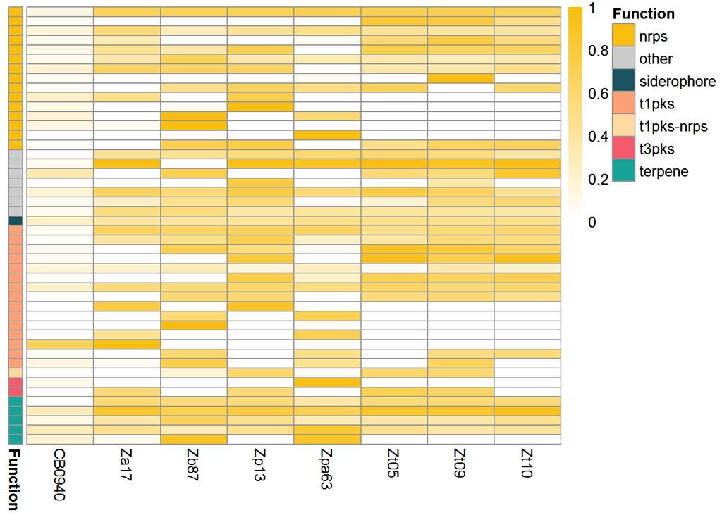

```r
temp = temp[order(temp$Function),]
cluster_found = colSums(temp[, c(2:9)])
temp[, c(2:9)] =  temp[, c(2:9)]/temp$Orthogroup

#To add the annotations on the left of the plot
rownames(temp) = temp$Consensus_name
ann = as.data.frame(temp$Function)
rownames(ann) = temp$Consensus_name
colnames(ann) = "Function"

phm2 = pheatmap(temp[, c(2:9)],
             color = colorRampPalette(c("#FFFFFF", my_colors[2]))(40),
             cluster_rows = FALSE,
             cluster_cols = FALSE,
         show_rownames = FALSE,
         annotation_row = ann,
         annotation_colors = list(Function = ann_colors))
phm2
```

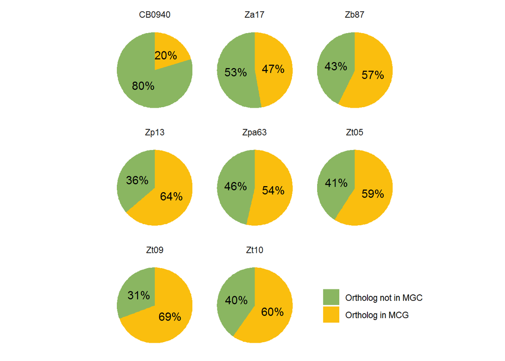

```r
diff = ortho_found-cluster_found
temp = data.frame(Cluster_found = cluster_found, Diff = diff, All = ortho_found)
temp$Percent_in_MGC = temp$Cluster_found * 100 / temp$All
temp$Percent_diff = temp$Diff * 100 / temp$All
temp$Sample = row.names(temp)
temp = gather(temp, "Percent_in_MGC", "Percent_diff", key = "Is_in_cluster", value = "Value")
d = ggplot(temp, aes(x="", y=Value, fill=Is_in_cluster)) +
  geom_bar(width = 1, stat = "identity") +
  coord_polar("y", start=0) +
  facet_wrap( ~ Sample) +
  theme_minimal() +
  scale_fill_manual(values = my_colors,
                    labels = c("Ortholog not in MGC",
                               "Ortholog in MCG")) +
  theme(
    axis.title.x = element_blank(),
    axis.title.y = element_blank(),
    panel.border = element_blank(),
    panel.grid=element_blank(),
    axis.ticks = element_blank(),
    plot.title=element_text(size=14, face="bold"),
    axis.text.x=element_blank(),
    legend.title = element_blank(),
    legend.position = c(0.9, 0.15)) +
  geom_text(aes(label = paste0(round(Value, 0), "%")),
               position = position_stack(vjust = 0.5), size = 4)
d
```

### Effectors

```r
effectors_ortho = large_table[which(large_table$Effector == "Effector"), "Orthogroup"]

effectors_only = large_table[which(large_table$Orthogroup %in% effectors_ortho),]
effectors_only$Effector[is.na(effectors_only$Effector)] = "NOPE"

temp = effectors_only[, c("Sample", "Effector", "Orthogroup")]

effectors = temp[!duplicated(paste0(temp$Sample, temp$Orthogroup)),] %>%
  spread(Sample, Effector)
```

## Producing circos inputs

### Synteny and pathogenicity related genes

```r
#Preparing the inputs for circos synteny
out_dir = "D:/Postdoc/Projects/Assembly_and_annotations/1_Assemblies/Circos/Circos_from_orthogroups/"
ref_tab = large_table %>% filter(Sample == reference_sample) %>%
  mutate(Contig = str_replace(Contig, "chr_", "Zt09_chr_"))
ref_effectors = ref_tab %>% filter(Effector == "Effector") %>%
  select(Contig, Start, End)


for (sample in our_samples) {
  out_effectors = paste0(out_dir, "Zt09_vs_", sample, "_pacbio_for_Circos.highlights")
  out_links = paste0(out_dir, "Zt09_vs_", sample, "_pacbio_for_Circos.links")
  out_contigs = paste0(out_dir, "Zt09_vs_", sample, "_pacbio_for_Circos.contigs")
  Zt_tab = large_table %>% filter(Sample == sample)


  #Effectors
  Zt_effectors = Zt_tab %>% filter(Effector == "Effector") %>%
    select(Contig, Start, End)

  bind_rows(ref_effectors, Zt_effectors) %>%
    write_delim(path = out_effectors, delim = " ", col_names = FALSE)


  #Links for genes (accessory and cores chromosomes are not sampled in the same density due to different gene densities)
  links = inner_join(ref_tab, Zt_tab, by = c("Orthogroup"))
  links_accessory = links[seq(1, nrow(links), 2), ] %>%
              separate(Contig.x, into = c("Ref_name", "contig_type", "Nb"),
                                  remove = FALSE, sep = "_", convert = TRUE) %>%
              filter(Nb >= 14)
  links_core = links[seq(1, nrow(links), 10), ] %>%
              separate(Contig.x, into = c("Ref_name", "contig_type", "Nb"),
                                  remove = FALSE, sep = "_", convert = TRUE) %>%
              filter(Nb < 14)

  links_to_write = bind_rows(links_accessory, links_core) %>%
    select(Contig.x, Start.x, End.x, Contig.y, Start.y, End.y)

  write_delim(x = links_to_write,
            path = out_links, delim = " ", col_names = FALSE)

  write(paste(unique(x = links$Contig.y), collapse = ';'), out_contigs)

}


#Zb vs Zp
out_links = paste0(out_dir, "Zb87_vs_Zp13_pacbio_for_Circos.links")
Zp_tab = large_table %>% filter(Sample == "Zp13")
Zb_tab = large_table %>% filter(Sample == "Zb87")
#Links for genes (accessory and cores chromosomes are not sampled in the same density due to different gene densities)
links = inner_join(Zp_tab, Zb_tab, by = c("Orthogroup"))
links = links[seq(1, nrow(links), 5), ] %>%
  select(Contig.x, Start.x, End.x, Contig.y, Start.y, End.y)

write_delim(x = links,
          path = out_links, delim = " ", col_names = FALSE)



for (sample in samples) {

  out_dir = "D:/Postdoc/Projects/Assembly_and_annotations/1_Assemblies/Circos/Circos_functions/"
  out_effectors = paste0(out_dir, sample, "_pacbio_for_Circos.effectors.highlights")
  out_MGC = paste0(out_dir, sample, "_pacbio_for_Circos.MGC.highlights")
  out_CAZymes = paste0(out_dir, sample, "_pacbio_for_Circos.CAZymes.highlights")
  sample_tab = large_table %>% filter(Sample == sample)

  #Effectors
  sample_tab %>% filter(Effector == "Effector") %>%
    mutate(Contig2 = paste(sample, Contig, sep = "_")) %>%
    select(Contig2, Start, End)  %>%
    write_delim(path = out_effectors, delim = " ", col_names = FALSE)

  #MGC
  sample_tab %>% filter(grepl("cluster", `Cluster(nb, function)`)) %>%
    mutate(Contig2 = paste(sample, Contig, sep = "_")) %>%
    select(Contig2, Start, End) %>%
    write_delim(path = out_MGC, delim = " ", col_names = FALSE)

  #CAZymes
  sample_tab %>% filter(CAZyme == "CAZyme") %>%
    mutate(Contig2 = paste(sample, Contig, sep = "_")) %>%
    select(Contig2, Start, End) %>%
    write_delim(path = out_CAZymes, delim = " ", col_names = FALSE)

}
```

### Genome compartmentalization

```r
if (exists("large_table")) {
  large_table = large_table
} else {
  large_table = read_tsv(all_table_file)
}

large_table$Specificity = ifelse(large_table$Specific_Zt %in% c("True", "TRUE"),
                             "Zt09", large_table$Specific_strain)

#large_table$Specificity = ifelse(large_table$Specific_Zt %in% c("True", "TRUE"),
##                             "Zt09",
#                             ifelse(large_table$Specific_strain == "Zp13",
#                                    "Zp13",
#                                    ifelse(large_table$Specific_strain == "Za17",
#                                           "Za17",
#                                           "Not_relevant")))

##Preparing the inputs for circos gene densities etc
in_dir = "D:/Postdoc/Projects/Assembly_and_annotations/2_Annotations/Chipseq/"
out_dir = "D:/Postdoc/Projects/Assembly_and_annotations/1_Assemblies/Circos/Circos_with_meth/"
#sample = "Zt09"
window_size = 100000


for (sample in c("Zt09", "Zp13", "Za17"))
{
#For H3K4 methylation
temp = read_tsv(paste0(in_dir, sample, "_H3K4_peaks_intersect_sorted.bed"), col_names = F) %>%
  mutate(window = paste(X1, round((X3+X2)/2/window_size, 0), sep = ":")) %>%
  group_by(window) %>%
  count() %>%
  separate(window, sep = ":", into = c("chromosome", "start"))

temp$chromosome = paste(sample, temp$chromosome, sep = "_")
temp$start = as.numeric(temp$start) * window_size
temp$stop = temp$start + (window_size - 1)

temp %>%
  select(chromosome, start, stop, n) %>%
  write_tsv(paste0(out_dir, sample, "_H3K4_peaks_density.bed"), col_names = F)

print(paste0(sample, "1"))
}
```

```
## [1] "Zt091"
```

```
## [1] "Zp131"
```

```
## [1] "Za171"
```

```r
for (sample in c("Zt09", "Zt05", "Zt10", "Zp13", "Zb87", "Za17"))
{
#For gene density
temp = large_table %>% filter(Sample == sample) %>%
  mutate(window = paste(Contig,
                        round((as.numeric(Start)+as.numeric(End))/2/window_size, 0),
                        sep = ":")) %>%
  group_by(window) %>%
  count() %>%
  separate(window, sep = ":", into = c("chromosome", "start"))

temp$chromosome = paste(sample, temp$chromosome, sep = "_")
temp$start = as.numeric(temp$start) * window_size
temp$stop = temp$start + (window_size - 1)

print(paste0(sample, "2"))

temp %>%
  select(chromosome, start, stop, n) %>%
  write_tsv(paste0(out_dir, sample, "_gene_density.bed"), col_names = F)

#For genes specific to Zt
temp = large_table %>% filter(Sample == sample) %>%
  filter(grepl(str_sub(sample, 1, 2), Specificity))

temp2 = temp %>% select(Contig, Start, End)
temp2$Contig = paste(sample, temp2$Contig, sep = "_")
write_tsv(temp2, paste0(out_dir, sample, "_spe_Zt.highlights.bed"), col_names = F)

temp = temp %>%
  mutate(window = paste(Contig,
                        round((as.numeric(Start)+as.numeric(End))/2/window_size, 0),
                        sep = ":")) %>%
  group_by(window) %>%
  count() %>%
  separate(window, sep = ":", into = c("chromosome", "start"))



temp$chromosome = paste(sample, temp$chromosome, sep = "_")
temp$start = as.numeric(temp$start) * window_size
temp$stop = temp$start + (window_size - 1)

print(paste0(sample, "3"))
temp %>%
  select(chromosome, start, stop, n) %>%
  write_tsv(paste0(out_dir, sample, "_spe_Zt.heatmap.bed"), col_names = F)


print(paste0(sample, "4"))
}
```

```
## [1] "Zt092"
## [1] "Zt093"
## [1] "Zt094"
## [1] "Zt052"
## [1] "Zt053"
## [1] "Zt054"
## [1] "Zt102"
## [1] "Zt103"
## [1] "Zt104"
## [1] "Zp132"
## [1] "Zp133"
## [1] "Zp134"
## [1] "Zb872"
## [1] "Zb873"
## [1] "Zb874"
## [1] "Za172"
## [1] "Za173"
## [1] "Za174"
```

```r
##Preparing the inputs for Circos TE density
temp = read_tsv(paste0(in_dir, sample, "_H3K4_peaks_intersect_sorted.bed"), col_names = F) %>%
  mutate(window = paste(X1, round((X3+X2)/2/window_size, 0), sep = ":")) %>%
  group_by(window) %>%
  count() %>%
  separate(window, sep = ":", into = c("chromosome", "start"))
```

```r
##Prepating the inputs for Circos TPMs
in_vitro_TPM = read.table("D:/Postdoc/Projects/Assembly_and_annotations/2_Annotations/Allinfo_Zymo_annotation_TPM.csv")
threshold_max_TPM = 10000
for (sample in samples) {
temp = in_vitro_TPM %>%
  filter(Sample == sample) %>%
  mutate(window = paste(paste(Sample, Contig, sep = "_"),
                        round((Start + End)/2/window_size, 0),
                        sep = ":")) %>%
  group_by(window) %>%
  summarize(median = round(median(Zymo_TPM, na.rm = T), 2)) %>%
  separate(window, sep = ":", into = c("chromosome", "start"))
median_of_median = median(temp$median)

#temp_plot = ggplot(temp, aes(median)) +
#  geom_density() +
###  geom_vline(aes(xintercept = median_of_median))+
#  geom_vline(aes(xintercept = threshold_max_TPM*median_of_median), color = "red") +
#  theme_minimal() +
#  xlab(paste0("median of TPM for ", sample))
#print(temp_plot)
#temp$median[temp$median > threshold_max_TPM*median_of_median] = threshold_max_TPM*median_of_median
#temp$chromosome = paste(sample, temp$chromosome, sep = "_")
temp$start = as.numeric(temp$start) * window_size
temp$stop = temp$start + (window_size - 1)

temp %>% mutate (log_median = log(median)) %>%
  select(chromosome, start, stop, log_median) %>%
  write_tsv(paste0(out_dir, sample, "_TPM.bed"), col_names = F)


}
```